# Manjeet Singh -Customer segmentation

Manjeet

September 22, 2018

# Load the important libraraies

```r
library(cluster)
library(fpc)
library(R2HTML)
```

# Import the data

```r
df <- read.csv("C:/Users/manjeet.singh/Downloads/churnModelBase_Assignment2 (3).csv")
dim(df)
```

```
## [1] 50000   112
```

```r
sum(is.na(df))
```

```
## [1] 211071
```

Select variables for cluster analysis.

I will pick here only 5 variables same like Churn prediction model. Three of the vriable si slected are not in the right format so i will convert them into the appropriate format.Once these are convereted into the right format the missing values will be replaced by NAs.

```r
df$ActiveSinceDays = as.numeric(as.integer(df$ActiveSinceDays))
df$Customer_status = as.numeric(as.integer(df$Customer_status))
df$dayssincelastload = as.numeric(as.integer(df$dayssincelastload))
```

# Subsetting

```r
data_cluster = subset(df,select =c(dayssincelastload,avgbal_m0,avg_rechX_m0,
                                   ActiveSinceDays,Customer_status) )
```

# Determine number of clusters.

[figure not shown]

```r
data_cluster <- na.omit(data_cluster) #List wise deletion of missing values
wss <- (nrow(data_cluster)-1)*sum(apply(data_cluster,2,var))
for(i in 2:20)wss[i] <- sum(kmeans(data_cluster,centers=i)$withinss)
par(mar=c(1,1,1,1))
plot(1:20, wss, type ="b",xlab = "number of cluster",
     ylab ="within groups sum of squares")
```

In x axis we have number of clusters, on Y axis we have with in cluser variances.

Initially the variance is high. As we keep on slpiltting into clutser, you can see cluster variance is keep on decreasing.But after certain period this cluster variance is almost stablised. If we have to choose the optimal number of cluster, we can choose 6,7,8. I am chhosing 6 clusters here.But it can eb changed.

Cluster = 6

```r
fit <- kmeans(data_cluster,6)
aggregate(data_cluster, by=list(fit$cluster), FUN = mean)
```

```
##   Group.1 dayssincelastload  avgbal_m0 avg_rechX_m0 ActiveSinceDays
## 1       1          40.60000 43551.5774     502.8291        581.9000
## 2       2          56.48999   166.1014     258.8001       1316.0760
## 3       3          50.79150  3735.7584     391.0536        733.4266
## 4       4          63.09083   145.1688     224.1224        375.2984
## 5       5          63.23590   465.3129    7237.2086        697.3897
## 6       6          60.17365 13466.4805     547.4457        707.6048
##   Customer_status
## 1        2.333333
## 2        3.039295
## 3        2.951303
## 4        3.103461
## 5        2.830769
## 6        2.664671
```

This is how clusters looks like. Overal, we can see how clusters are different from each other.

It is very important to attach data cluster into dataset.

```r
data_cluster = data.frame(data_cluster, fit$cluster)
```

Number of elemets in each cluster. I have chooses randomly 6 thats why we have this little inconsistency.

```r
table(data_cluster$fit.cluster)
```

```
##
##     1     2     3     4     5     6
##    30 17127  1458 29615   195   167
```

Centroid Plot

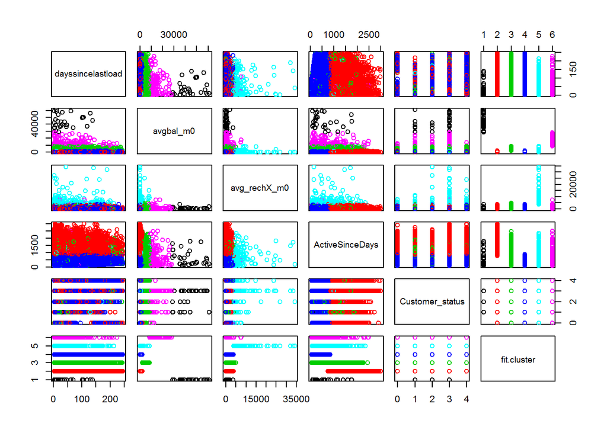

```r
plot(data_cluster, col = fit$cluster)
points(fit$cluster, col = 4:22, pch = 8, ces =2)
```

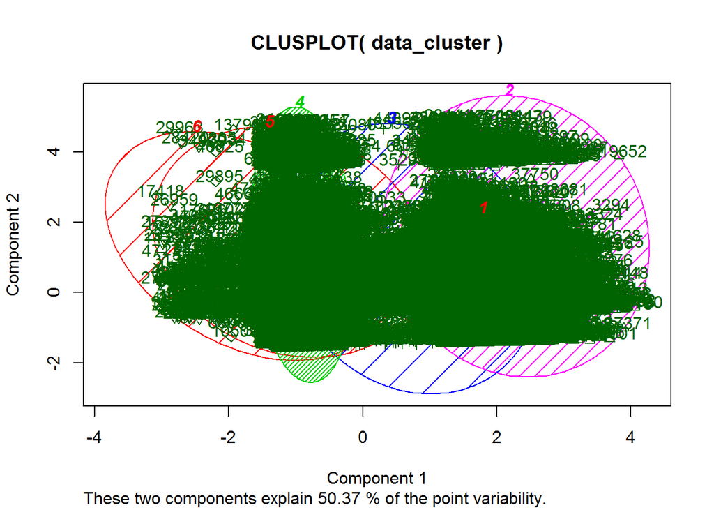

```r
clusplot(data_cluster, fit$cluster, color = TRUE,shade = TRUE, labels =2, lines = 0)
```

Plot of clutsers. We can see 6 clusters.

We have plotted all 48000+ observations by computing 2 principal componants. by Reducing 5 attributes into two attributes by computing two PC and then plotting the observations.